# Telecommunications Marketing Survey Report

Melissa Wu

July 11, 2023

# Calculations

### Q1: Respondent Variables

#### Age Group

What are the distribution of respondents across **age groups**?

|  | x | N |
| --- | --- | --- |
| 1 | 18-34 | 30.6 |
| 2 | 35-49 | 27.8 |
| 3 | 50-64 | 27.2 |
| 4 | 65+ | 14.4 |

#### Gender

What are the distribution of respondents across **gender**?

|  | x | N |
| --- | --- | --- |
| 1 | Female | 52 |
| 2 | Male | 46.9 |
| 3 | Other | 1 |

#### Income Group

What are the distribution of respondents across **income groups**?

|  | x | N |
| --- | --- | --- |
| 1 | Under 50,000 | 33.1 |
| 2 | 50,000 - Under 75,000 | 11.4 |
| 3 | 75,000 - Under 100,000 | 24.6 |
| 4 | 100,000 - Under 150,000 | 22.1 |
| 5 | 150,000+ | 8.8 |

#### Region

What are the distribution of respondents across **region**?

|  | x | N |
| --- | --- | --- |
| 1 | Midwest | 24.6 |
| 2 | Northeast | 19.5 |
| 3 | South | 29.9 |
| 4 | West | 26.1 |

#### Persona

What are the distribution of respondents across **persona**?

|  | x | N |
| --- | --- | --- |
| 1 | Ambivalent Adventurer | 19.3 |
| 2 | Consistent Compromiser | 26.7 |
| 3 | Materialistic Meditator | 16.1 |
| 4 | Outdoorsy Ombudsman | 5.4 |
| 5 | Precociously Preoccupied | 24 |
| 6 | Technological Triumphalist | 8.5 |

### Q2: Segmented Outcomes

#### Part A

What are the top 5 products by Awareness rates in the Northeast?

|  | Product | Mean |
| --- | --- | --- |
| 1 | Speed Dials | 86.31 |
| 2 | Maybe Mobile | 86.21 |
| 3 | Triumphone | 83.97 |
| 4 | Mobzilla | 74.13 |
| 5 | Communic Nation | 71.37 |

#### Part B

What are the top 5 products by advocacy rates among female respondents who earn at least $100,000?

|  | Product | Mean |
| --- | --- | --- |
| 1 | MobilitEE | 86.12 |
| 2 | Triumphone | 84.31 |
| 3 | No Buttons | 83.01 |
| 4 | Next Text | 82.99 |
| 5 | Ring Ring | 77.27 |

### Q3: Overall Brand Perceptions

What are the top 5 brands by the overall average perception?

|  | Product | overall.ave.perception |
| --- | --- | --- |
| 1 | Next Text | 7.12 |
| 2 | Cellularity | 6.85 |
| 3 | All Buttons | 6.47 |
| 4 | MobilitEE | 6.1 |
| 5 | Off the Hook | 6.06 |

### Q4: Gaps in Outcomes

#### Part A

Which 5 products have the largest gap between the rate of consumption and the rate of awareness? This would correspond to a formula of Difference = 100 * (Average Consumption - Average Awareness). (Please use this exact formula. Do not use the absolute value. Focus only on the highest positive gaps.) Display a bar graph showing the 5 largest differences in decreasing sorted order.

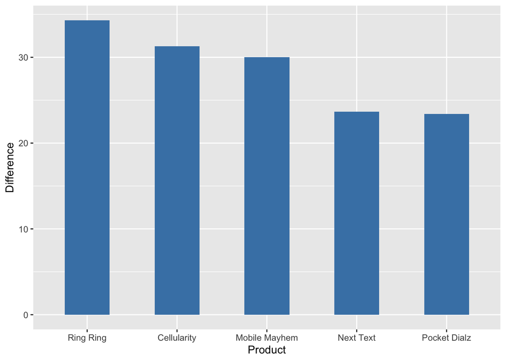

#### Part B

Which 5 products have the largest gap between the rate of awareness and the average satisfaction? This would correspond to a formula of Difference = 100 * (Average Awareness - Average Satisfaction). (Please use this exact formula. Do not use the absolute value. Focus only on the highest positive gaps.) Display a bar graph showing the 5 largest differences in decreasing sorted order.

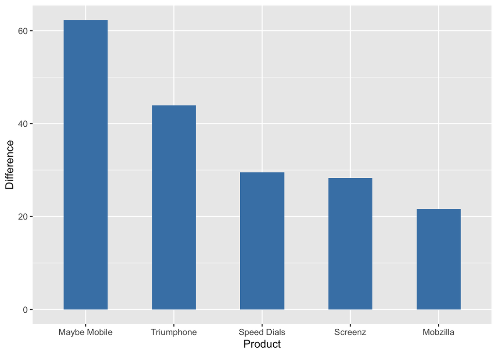

### Q5: Aggregated Engagement

#### Part A

How much impact does respondent’s overall trends in awareness have for that person’s awareness with Buzzdial phones?

|  | rn | Estimate | Std. Error | z value | Pr(>\|z\|) | Odds.Ratio | OR.Lower.95 | OR.Upper.95 |
| --- | --- | --- | --- | --- | --- | --- | --- | --- |
| 1 | (Intercept) | -0.44 | 0.034 | -12.907 | 0 | 0.644 | 0.602 | 0.689 |
| 2 | age.group35-49 | -0.215 | 0.013 | -16.234 | 0 | 0.807 | 0.786 | 0.828 |
| 3 | age.group50-64 | -0.714 | 0.014 | -49.953 | 0 | 0.49 | 0.476 | 0.504 |
| 4 | age.group65+ | -0.779 | 0.018 | -43.313 | 0 | 0.459 | 0.443 | 0.476 |
| 5 | genderMale | -0.253 | 0.011 | -23.54 | 0 | 0.776 | 0.76 | 0.793 |
| 6 | income50,000 - Under 75,000 | -0.018 | 0.018 | -0.983 | 0.326 | 0.982 | 0.947 | 1.018 |
| 7 | income75,000 - Under 100,000 | 0.022 | 0.014 | 1.56 | 0.119 | 1.022 | 0.994 | 1.051 |
| 8 | income100,000 - Under 150,000 | 0.034 | 0.015 | 2.332 | 0.02 | 1.035 | 1.005 | 1.065 |
| 9 | income150,000+ | 0.131 | 0.02 | 6.608 | 0 | 1.141 | 1.097 | 1.186 |
| 10 | regionNortheast | 0.291 | 0.016 | 17.706 | 0 | 1.338 | 1.295 | 1.382 |

[output cut: 8 more lines]

#### Part B

How much impact does respondent’s overall trends in satisfaction have for that person’s satisfaction with Buzzdial phones?

|  | rn | Estimate | Std. Error | t value | Pr(>\|t\|) | Coef.Lower.95 | Coef.Upper.95 |
| --- | --- | --- | --- | --- | --- | --- | --- |
| 1 | (Intercept) | 0.243 | 0.005 | 45.25 | 0 | 0.233 | 0.254 |
| 2 | age.group35-49 | -0.044 | 0.003 | -16.322 | 0 | -0.05 | -0.039 |
| 3 | age.group50-64 | -0.138 | 0.003 | -50.457 | 0 | -0.143 | -0.132 |
| 4 | age.group65+ | -0.135 | 0.003 | -40.455 | 0 | -0.141 | -0.128 |
| 5 | genderMale | -0.047 | 0.002 | -22.704 | 0 | -0.051 | -0.043 |
| 6 | income50,000 - Under 75,000 | -0.012 | 0.004 | -3.227 | 0.001 | -0.019 | -0.005 |
| 7 | income75,000 - Under 100,000 | 0.001 | 0.003 | 0.46 | 0.646 | -0.004 | 0.007 |
| 8 | income100,000 - Under 150,000 | 0 | 0.003 | -0.031 | 0.975 | -0.006 | 0.005 |
| 9 | income150,000+ | 0.02 | 0.004 | 5.122 | 0 | 0.012 | 0.028 |
| 10 | regionNortheast | 0.065 | 0.003 | 20.413 | 0 | 0.058 | 0.071 |

[output cut: 8 more lines]